# Cannibalization of organic search visits due to SEM

### (A) Linear Regression

> *Are there other statistical methods that can show the impact of SEM visits on SEO visits?*

In the current approach, the influence of time on results has been eliminated. Multivariate linear regression can utilize multiple features (in this case, `Weeks`) to fit the dependent variable. Since, the dataset contains only one feature, a linear regression might suffice in this case. However, for a dataset with large number of features, one could use feature selection based on variable importances by using [Random Forest](http://en.wikipedia.org/wiki/Random_forest) or [Classification trees](http://en.wikipedia.org/wiki/Decision_tree_learning). For a more complicated dataset, non-linear regression could also be applied. An alternative approach to look at the relationship would be to treat the data as a [time series](http://en.wikipedia.org/wiki/Time_series).

### (B) Model Validation

> *What does the result of the coefficients tell you about the regression function and the data?*

Negative coefficient indicates that SEM and SEO are inversely related which means when SEM increases, SEO downfalls. This confirms the initial hypothesis that SEM negatively impacts SEO.

> *Determining how well the data fits into your regression function can be done by calculating the correlation coefficient. However, it is also known that this is not a good measure of model validation. What other approaches could you use? Feel free to program this if you wish.*

There are several other regression metrics which give more confidence about the model we are building. Let $\hat{y}$ be the estimated value and $y$ be the actual value or ground truth.

**Explained Variance Score**: $1 - \dfrac{Var(y-\hat{y})}{Var(y)}$ which looks at dispersion of values which is the ratio of the variance of difference of the estimated and actual values with respect to the variance of the actual value.

**Mean Absolute Error**: $\dfrac{1}{n_\mathrm{samples}} \sum\limits_1^{n_\mathrm{samples}} \left | y - \hat{y} \right |$ where one looks at the $l_1$ norm (distance) for the two vectors corresponding to estimated and actual values.

**Mean Squared Error**: $\dfrac{1}{n_\mathrm{samples}} \sum\limits_1^{n_\mathrm{samples}} ( y - \hat{y} )^2$ is in a similar way the $l_2$ norm (squared distance measure) between estimated and actual vectors.

All the above measures are available in [sklearn.metrics](http://scikit-learn.org/stable/modules/classes.html#regression-metrics)

## Bonus

> *Provide tests to accompany your python functions. At nugit, we use unittest and nose with codecoverage.*
- I have included a `unittest` and the `codecoverage` results in the submission files. The unittest was built to check for gradient, intercept, $r$, $R^2$ values. Of course, it should be extended to look for data errors and mismatches in data types. But due to shortage of time, I am just putting a small test at this point of time.

> *Provide an approach to remove outliers. Feel free to program this.*
- A standard approach to eliminating outliers is to keep data within $\mu\ \pm\ 3 \sigma$ where $\mu$ is the mean and $\sigma$ is the standard deviation. Boxplots are helpful in visualizing this. However, this may be flawed since mean can be severely affected if number of outliers is large.
- Since we are dealing with regression, we can identify outliers by looking at the errors in our predicted values as compared to the actual values. I have written the following snippet which identifies outliers which fall beyond 90 percentile limit on the error estimates.
- Other state-of-the-art outlier detection methods exists like OneClassSVM and [Mahalanobis Distance](http://en.wikipedia.org/wiki/Mahalanobis_distance) measure.

```python
import pandas as pd
from sklearn.linear_model import LinearRegression

def get_outlier_idx(linear_fit, X, y, percentile_threshhold):

    errors = (y - linear_fit.predict(X))
    outlier_idx = errors.values >= np.percentile(errors.values, percentile_threshhold)
    return outlier_idx

data = pd.DataFrame.from_csv("sample_data_Oct.csv", sep='\t', index_col=False)
X = data[['SEM']]
y = data[['SEO']]
model = LinearRegression()
lin_fit = model.fit(X,y)
print "Outliers based on 90% error threshold"
data[get_outlier_idx(lin_fit, X, y, 90)]
```

```
Outliers based on 90% error threshold
```

|  | Week | SEM | SEO |
| --- | --- | --- | --- |
| 27 | 27 | 15433 | 102333 |
| 31 | 31 | 45465 | 82953 |
| 35 | 35 | 37541 | 87549 |
| 36 | 36 | 22003 | 102033 |

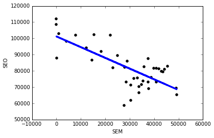

```python
# Original linear regression without detrend
import matplotlib.pyplot as plt

plt.scatter(X, y, color='black')
plt.plot(X, lin_fit.predict(X), color='blue',
         linewidth=3)
plt.xlabel('SEM')
plt.ylabel('SEO')
plt.show()
```

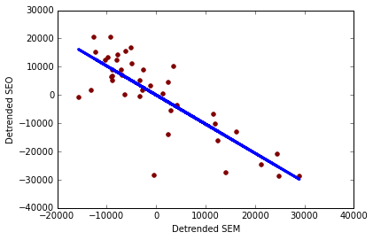

```
Naive Linear regression R^2      : 0.5415
Detrend Dataset R^2              : 0.6804
Naive Linear Regression gradient :-0.66
Detrend gradient                 :-1.03
```

```python
from scipy.signal import detrend
SEO_detrend = pd.DataFrame(detrend(data['SEO']))
SEM_detrend = pd.DataFrame(detrend(data['SEM']))

model = LinearRegression()
lin_fit_detrend = model.fit(SEO_detrend, SEM_detrend)

plt.scatter(SEO_detrend, SEM_detrend, color='maroon')
plt.plot(SEO_detrend, lin_fit_detrend.predict(SEO_detrend), color = 'blue',
         linewidth=3)
plt.xlabel('Detrended SEM')
plt.ylabel('Detrended SEO')
plt.show()
from scipy.stats.stats import pearsonr
r_detrend, _ = pearsonr(SEM_detrend, SEO_detrend)
print("Naive Linear regression R^2 : " +
      str(round(lin_fit.score(X,y), 4)))
print("Detrend Dataset R^2                 : " +
      str(round(lin_fit_detrend.score(SEO_detrend, SEM_detrend), 4)))

print("Naive Linear Regression gradient :" + str(round(lin_fit.coef_,2)))
print("Detrend gradient                 :" + str(round(lin_fit_detrend.coef_,2)))
```

With detrend of data, we observe a better $R^2$ and a bigger gradient indicating the relationship is stronger than previously estimated.

> *Chart your results using any JavaScript library*